# Unsupervised Learning: Trade & Ahead

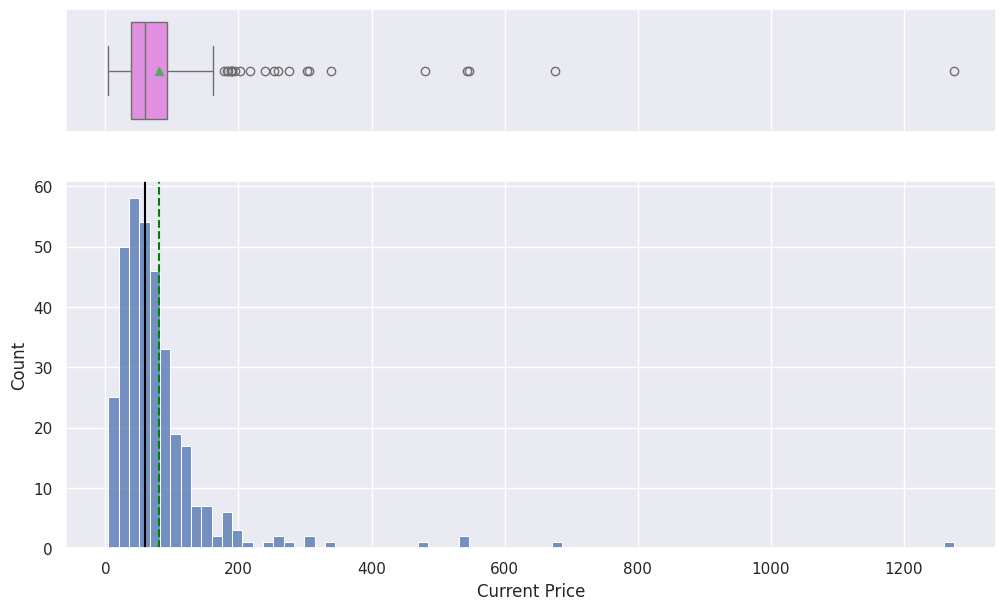

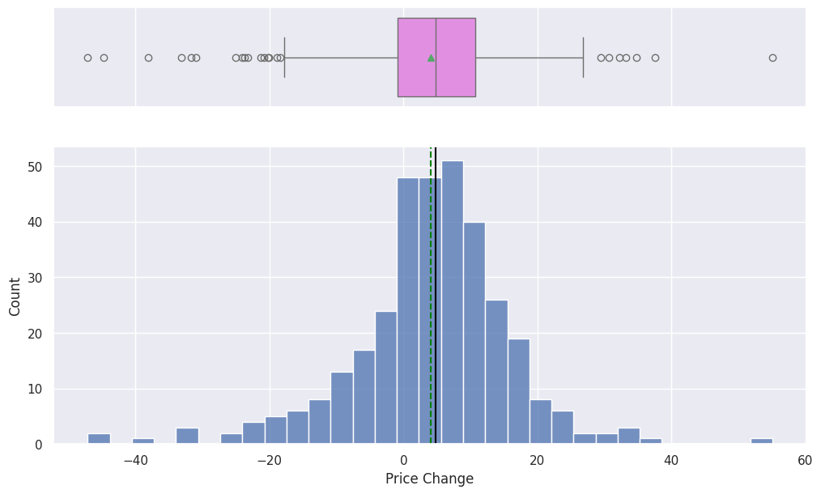

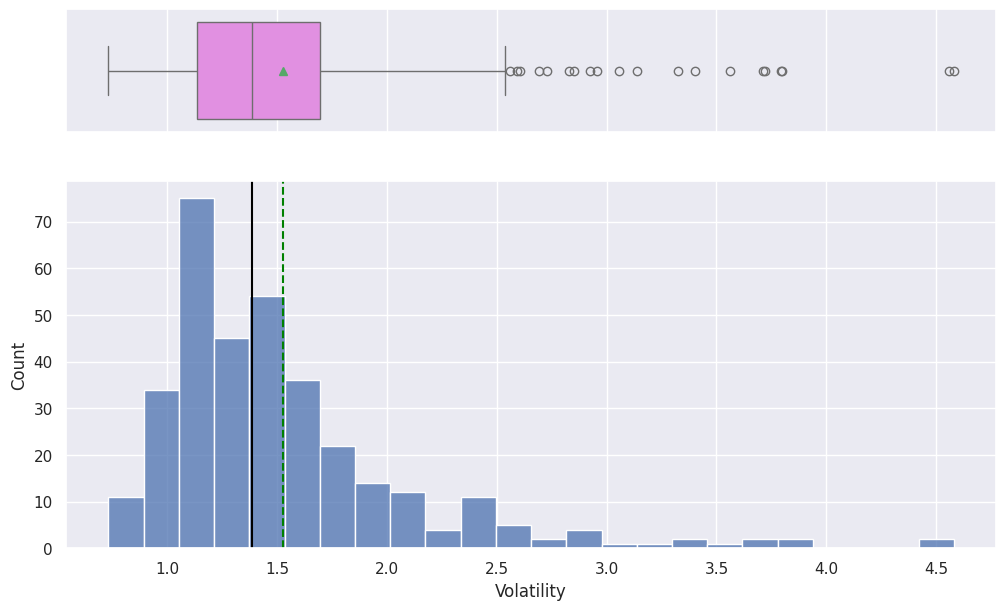

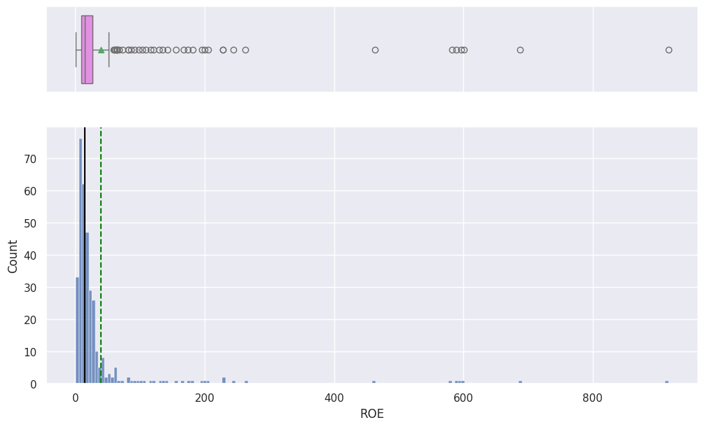

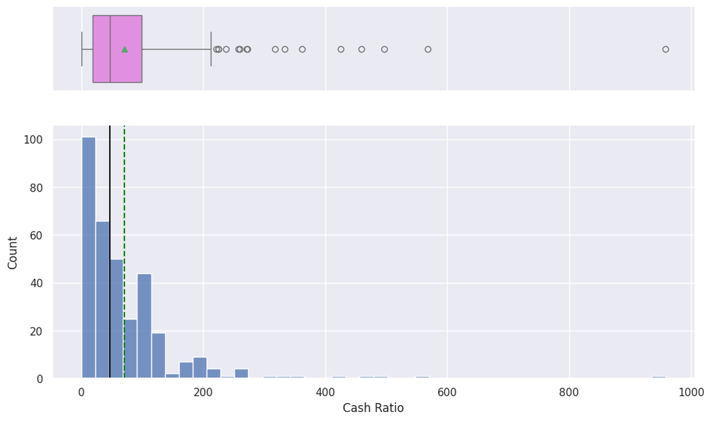

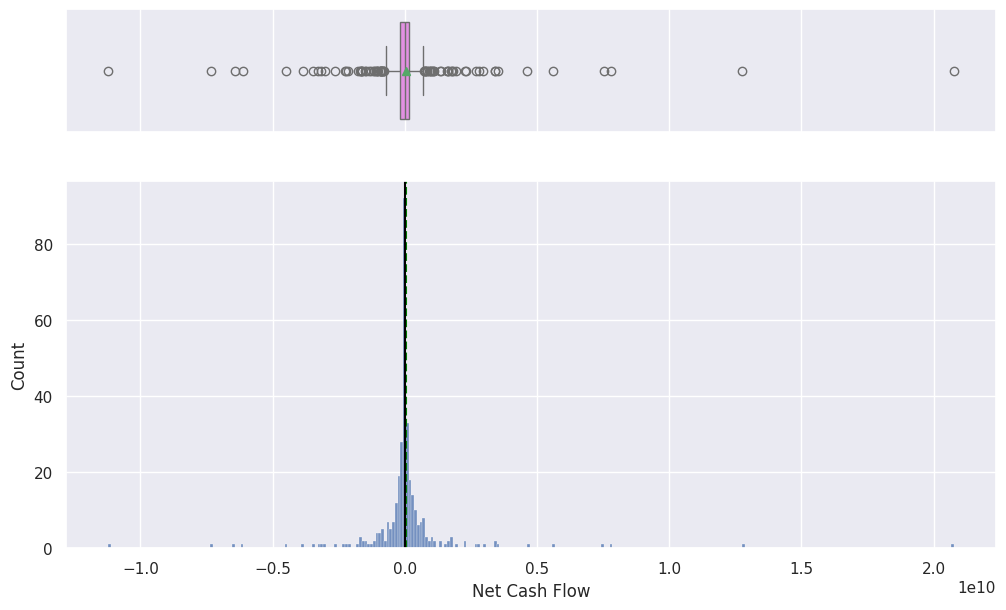

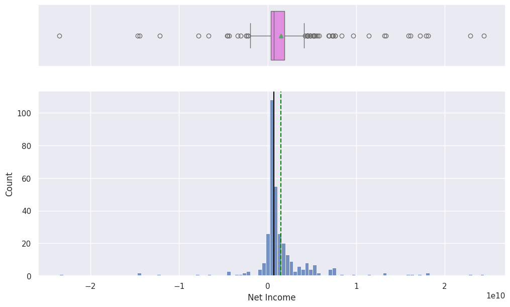

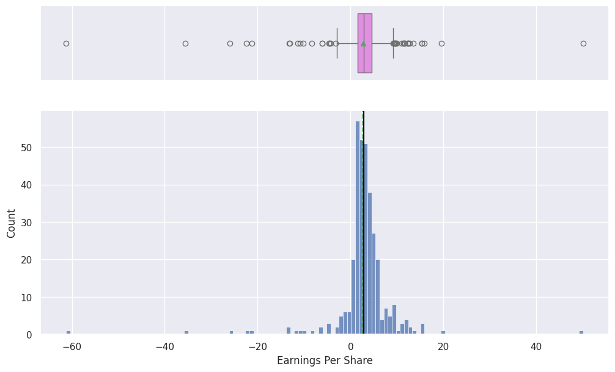

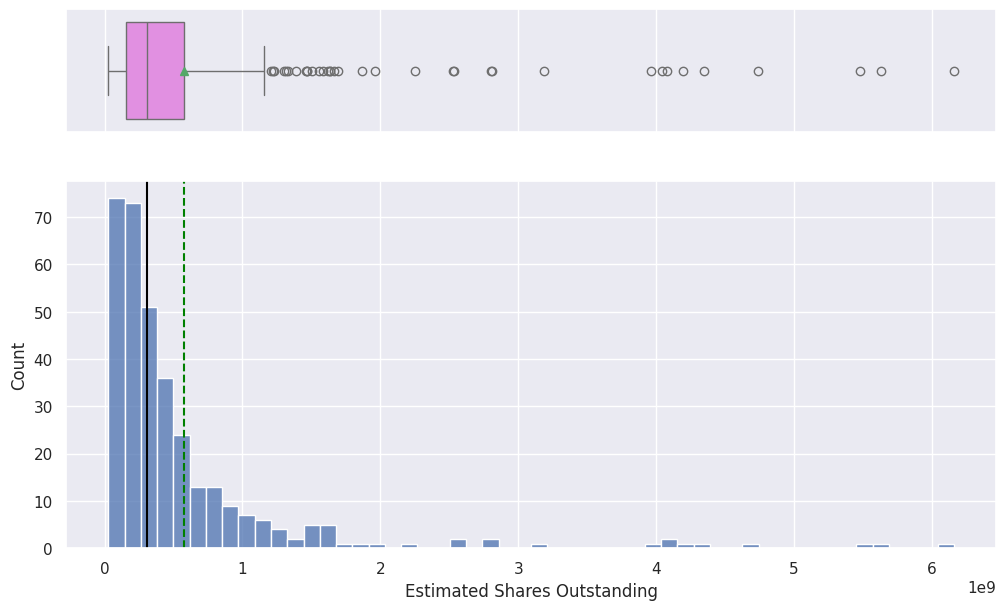

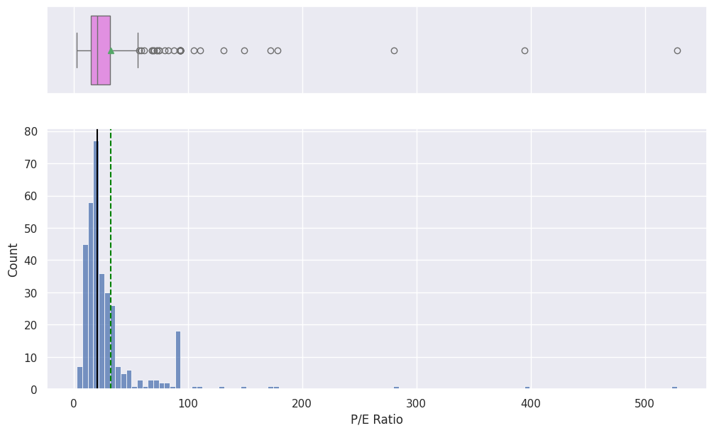

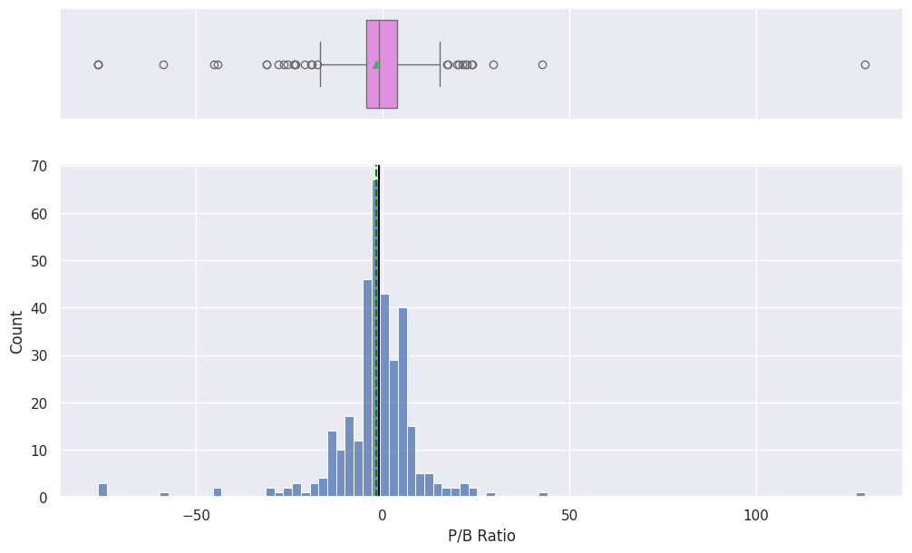

```python
# Filter only numeric columns for original dataframe 'data' so as to get the original dataset univariate analysis before data manipulation
numeric_cols = data.select_dtypes(include='number').columns

# Plot histogram + boxplot for each numeric feature
for feature in numeric_cols:
    histogram_boxplot(data, feature, figsize=(12, 7), kde=False, bins=None)
```

Key Observations/Insights:

Current Price

- Highly right-skewed with extreme outliers (up to $1200+).
- Most prices are between $10–$150.
  - Suggests log transformation may help normalize for modeling or clustering.

Price Change

- Fairly symmetric distribution around zero.
- Range includes both strong negative and positive changes (–50% to +50%).
  - Good candidate as-is for models, though standardization is advisable.

Volatility

- Right-skewed distribution; most values between 1–2.5
- Some outliers above 4.5
  - Could apply log transform or robust scaling for better model stability.

ROE (Return on Equity)

- Extremely skewed right, with outliers above 800%.
- Bulk of observations under 50%.
  - High outliers could distort results; suggest winsorizing or log transform.

Cash Ratio

- Right-skewed with many low values, but extreme highs above 800.
- May indicate cash-heavy companies or potential data issues.
  - Suggest log transformation or capping extreme values.

Net Cash Flow

- Very tight central peak around zero with heavy tails.
- Lots of variance — possibly due to company size disparities.
  - Strong candidate for log transformation after shifting to positive domain if needed.

Net Income

- Distribution centered near 0 but with a heavy tail on the positive side.
- Many companies have losses (negative tail), but some have massive earnings.
  - Consider log1p after handling negatives (by shift or two-sided log).

Earnings Per Share (EPS)

- Sharp central peak with long tails on both sides.
- Some firms show large negative EPS (losses), others very high positive EPS.
  - Apply standardization or log transform (with care for negatives).

Estimated Shares Outstanding

- Highly right-skewed; most firms have fewer than 500M shares, but some exceed 5B.
  - Good candidate for log scale or min-max scaling.

P/E Ratio

- Right-skewed with values exceeding 500.
- Majority of companies between 5–50.
  - Suggest log transformation to compress the scale.

P/E Ratio (Price-to-Earnings)

- Highly right-skewed distribution.
- The majority of values fall between 5 and 40, with a few extreme outliers (P/E > 500).
  - Apply log transformation to compress the range and reduce skew. Consider Winsorizing or capping extreme values (e.g., top 1%).

P/B Ratio (Price-to-Book)

- P/B ratios near zero may indicate undervaluation or distressed assets.
- Negative or very high values may either signal true business states (e.g., heavy losses, asset-light models) or data quality issues.
  - Consider flagging and investigating negative book values for interpretability. Apply log transformation carefully

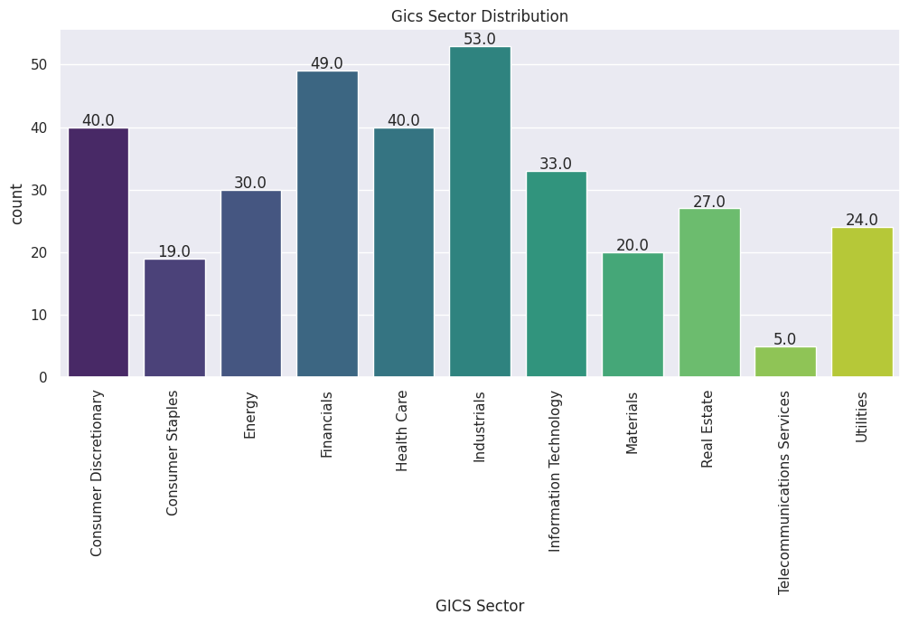

```python
# labeled Barplot GICS Sector
labeled_barplot(data, 'GICS Sector')
```

Observations/Insights:

- The dataset is relatively well diversified across GICS sectors.
- Top 3 sectors by count: Industrials (53); Financials (49); Consumer Discretionary (40)
- Least represented: Telecommunications Services (5); Consumer Staples (19); Materials (20)
- Dataset is skewed toward Industrials and Financials, which may influence clustering or PCA if sector information correlates with other features.
- Underrepresentation in sectors like Telecom may mean these clusters will be small or less stable.

[figure not shown]

```python
# labeled Barplot GICS Sub Industry
labeled_barplot(data, 'GICS Sub Industry')
```

Observations/Insights:

- Sub-industries are numerous and varied, creating a long-tail distribution.
- A few sub-industries dominate the dataset:
  - Banks, Industrial Machinery, Health Care Equipment, etc., stand out clearly.
- Many sub-industries have 5 or fewer companies, indicating a highly granular breakdown.

There is diversity at the sub-industry level, which is great for fine-grained analysis.

```python
# Analyze top 5 highest or lowest priced stocks

# Top 5 highest priced stocks
top_5_highest = data.nlargest(5, 'Current Price')
display(top_5_highest.style.set_caption("Top 5 Highest Priced Stocks"))

# Top 5 lowest priced stocks
top_5_lowest = data.nsmallest(5, 'Current Price')
display(top_5_lowest.style.set_caption("Top 5 Lowest Priced Stocks"))
```

Top 5 Highest Priced Stocks

|  | Ticker Symbol | Security | GICS Sector | GICS Sub Industry | Current Price | Price Change | Volatility | ROE | Cash Ratio | Net Cash Flow | Net Income | Earnings Per Share | Estimated Shares Outstanding | P/E Ratio | P/B Ratio |
| --- | --- | --- | --- | --- | --- | --- | --- | --- | --- | --- | --- | --- | --- | --- | --- |
| 243 | PCLN | Priceline.com Inc | Consumer Discretionary | Internet & Direct Marketing Retail | 1274.949951 | 3.190527 | 1.268340 | 29 | 184 | -1671386000 | 2551360000 | 50.090000 | 50935516.070000 | 25.453183 | -1.052429 |
| 26 | AMZN | Amazon.com Inc | Consumer Discretionary | Internet & Direct Marketing Retail | 675.890015 | 32.268105 | 1.460386 | 4 | 58 | 1333000000 | 596000000 | 1.280000 | 465625000.000000 | 528.039074 | 3.904430 |
| 171 | ISRG | Intuitive Surgical Inc. | Health Care | Health Care Equipment | 546.159973 | 18.733013 | 1.126009 | 14 | 317 | 114300000 | 588800000 | 15.870000 | 37101449.280000 | 34.414617 | 42.607500 |
| 264 | REGN | Regeneron | Health Care | Biotechnology | 542.869995 | 16.995320 | 1.802345 | 17 | 129 | 160383000 | 636056000 | 6.170000 | 103088492.700000 | 87.985412 | 20.409000 |
| 70 | CMG | Chipotle Mexican Grill | Consumer Discretionary | Restaurants | 479.850006 | -33.131268 | 2.474002 | 22 | 237 | -171460000 | 475602000 | 15.300000 | 31085098.040000 | 31.362745 | 17.201329 |

Top 5 Lowest Priced Stocks

|  | Ticker Symbol | Security | GICS Sector | GICS Sub Industry | Current Price | Price Change | Volatility | ROE | Cash Ratio | Net Cash Flow | Net Income | Earnings Per Share | Estimated Shares Outstanding | P/E Ratio | P/B Ratio |
| --- | --- | --- | --- | --- | --- | --- | --- | --- | --- | --- | --- | --- | --- | --- | --- |
| 62 | CHK | Chesapeake Energy | Energy | Integrated Oil & Gas | 4.500000 | -38.101788 | 4.559815 | 687 | 22 | -3283000000 | -14685000000 | -22.430000 | 654703522.100000 | 28.407929 | -1.840528 |
| 137 | FTR | Frontier Communications | Telecommunications Services | Integrated Telecommunications Services | 4.670000 | -2.301255 | 2.026818 | 3 | 496 | 254000000 | -196000000 | -0.290000 | 675862069.000000 | 14.518987 | 10.497704 |
| 127 | FCX | Freeport-McMoran Cp & Gld | Materials | Copper | 6.770000 | -31.685167 | 3.796410 | 155 | 5 | -240000000 | -12156000000 | -11.310000 | 1074801061.000000 | 22.811951 | 2.935427 |
| 284 | SWN | Southwestern Energy | Energy | Oil & Gas Exploration & Production | 7.110000 | -44.798137 | 4.580042 | 200 | 2 | -38000000 | -4556000000 | -6.070000 | 402141680.400000 | 93.089287 | 1.273530 |
| 33 | ARNC | Arconic Inc | Industrials | Aerospace & Defense | 7.398807 | 1.647784 | 2.592065 | 3 | 37 | 42000000 | -322000000 | -0.310000 | 1038709677.000000 | 18.687607 | 2.639814 |

Observations:

- As seen top 5 highest or lowest priced stocks

## Bivariate Analysis:

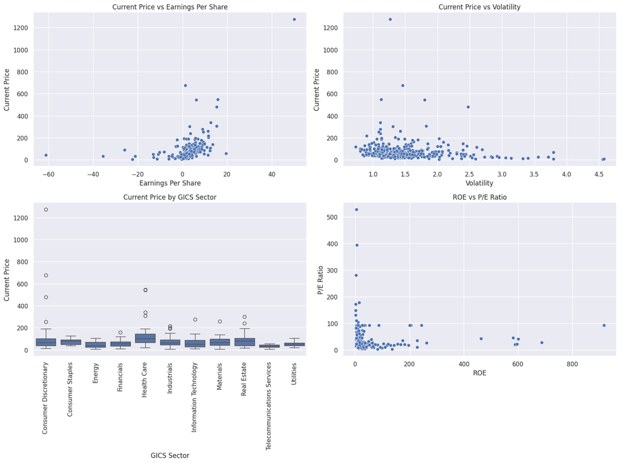

```python
# Current Price relationship to another variable

# Create subplots for bivariate analysis
fig, axes = plt.subplots(2, 2, figsize=(16, 12));

# Current Price vs Earnings Per Share (scatter plot)
sns.scatterplot(data=df, x='Earnings Per Share', y='Current Price', ax=axes[0, 0])
axes[0, 0].set_title('Current Price vs Earnings Per Share')

# Current Price vs Volatility (scatter plot)
sns.scatterplot(data=df, x='Volatility', y='Current Price', ax=axes[0, 1])
axes[0, 1].set_title('Current Price vs Volatility')

# Current Price by GICS Sector (boxplot)
sns.boxplot(data=df, x='GICS Sector', y='Current Price', ax=axes[1, 0])
axes[1, 0].set_title('Current Price by GICS Sector')
axes[1, 0].tick_params(axis='x', rotation=90)

# ROE vs P/E Ratio (scatter plot)
sns.scatterplot(data=df, x='ROE', y='P/E Ratio', ax=axes[1, 1])
axes[1, 1].set_title('ROE vs P/E Ratio')

plt.tight_layout()
plt.show()
```

Key Observations/Insights:

**Current Price vs Earnings Per Share (EPS):**

As expected, a positive correlation,higher EPS tends to align with higher stock prices.

A few extreme EPS values (both negative and positive) create vertical spreads.

A cluster is concentrated around EPS ≈ 0–20 and Price ≈ 0–200.

- While expected, not all high-priced stocks have high EPS, hinting at speculative pricing or growth expectations.

**Current Price vs Volatility:**

No strong linear pattern, but there’s a dense concentration of low-volatility, moderately priced stocks.

Very high-priced stocks (> $800) still have moderate to low volatility.

- Most high-priced stocks are not necessarily more volatile, suggesting price is not equal to risk in this dataset.

**Current Price by GICS Sector:**

Wide spread of prices within most sectors.

Median prices look fairly consistent across sectors (approx. $50–$100 range).

- Sector is not a strong driver of price in this sample — within-sector variation outweighs between-sector differences.

**ROE vs P/E Ratio:**

Majority of stocks cluster at low ROE and low P/E (bottom-left).

No obvious linear trend — but many high P/E firms have low to moderate ROE.

- Inverse cases (low ROE, high P/E) may be overvalued growth stocks or early-stage firms.
- Suggests P/E alone is insufficient to judge return efficiency — useful for cluster profiling or flagging outliers.

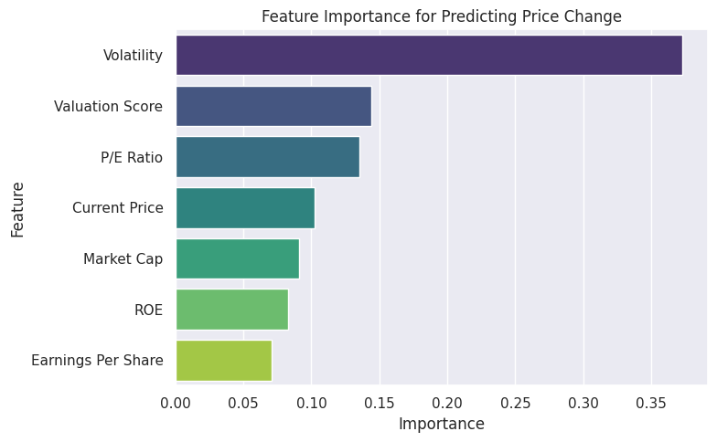

|  | Feature | Importance |
| --- | --- | --- |
| 0 | Volatility | 0.373027 |
| 1 | Valuation Score | 0.143929 |
| 2 | P/E Ratio | 0.135463 |
| 3 | Current Price | 0.102500 |
| 4 | Market Cap | 0.091049 |
| 5 | ROE | 0.082989 |
| 6 | Earnings Per Share | 0.071043 |

```python
# Identify features most predictive of a target variable (Price Change and EPS)

from sklearn.ensemble import RandomForestRegressor
from sklearn.model_selection import train_test_split

# Select features and target
features = [
    'Current Price', 'Volatility', 'ROE', 'P/E Ratio',
    'Earnings Per Share', 'Market Cap', 'Valuation Score'
]
X = df_clean[features]
y = df_clean['Price Change']

# Split data
X_train, X_test, y_train, y_test = train_test_split(X, y, random_state=1)

# Fit Random Forest for feature importance
rf = RandomForestRegressor(n_estimators=100, random_state=1)
rf.fit(X_train, y_train)

# Extract and rank feature importances
importances = rf.feature_importances_
feature_importance_df = pd.DataFrame({'Feature': features, 'Importance': importances})
feature_importance_df = feature_importance_df.sort_values(by='Importance', ascending=False)

# Visualize
plt.figure(figsize=(8, 5))
sns.barplot(data=feature_importance_df, x='Importance', y='Feature', palette='viridis')
plt.title("Feature Importance for Predicting Price Change")
plt.tight_layout()
plt.show()

feature_importance_df.reset_index(drop=True)
```

Observations/Insights:

- Volatility dominates: Stocks that swing more are understandably the most sensitive to price changes — this aligns with both theory and practice.
- Valuation indicators (Valuation Score, P/E Ratio) are also critical, reinforcing that perceived value or mispricing drives returns.
- Fundamentals like ROE and EPS contribute less directly to short-term price movement — they may be better indicators of long-term growth.

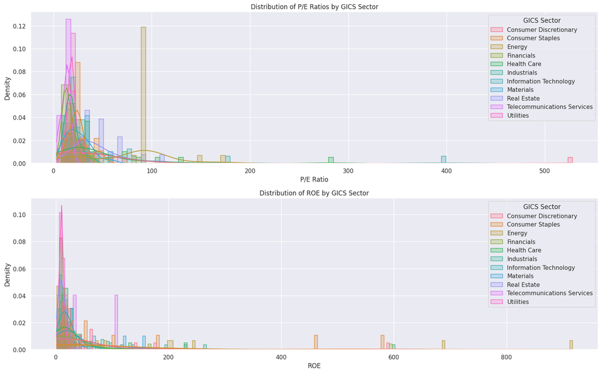

```python
# Distribution of P/E ratios & ROE within sectors
plt.figure(figsize=(16, 10));

# Plot P/E Ratio distribution by sector
plt.subplot(2, 1, 1)
sns.histplot(data=df, x='P/E Ratio', hue='GICS Sector', element='step', stat='density', common_norm=False, kde=True)
plt.title("Distribution of P/E Ratios by GICS Sector")
plt.xlabel("P/E Ratio")

# Plot ROE distribution by sector
plt.subplot(2, 1, 2)
sns.histplot(data=df, x='ROE', hue='GICS Sector', element='step', stat='density', common_norm=False, kde=True)
plt.title("Distribution of ROE by GICS Sector")
plt.xlabel("ROE")

plt.tight_layout()
plt.show()
```

Observations/Insights:

**P/E Ratio by GICS Sector:**

Skewed distributions: Most sectors show right-skewed P/E ratios, concentrated under 50 but with long tails extending past 500.

Consumer Staples and Utilities appear to have tight, left-heavy distributions — possibly indicating stable, low-growth valuation profiles.

Tech and Health Care show broader distributions, suggesting more variability in investor expectations.

- High P/E spread in sectors like Tech, Health Care, and Energy may reflect speculative pricing or growth narratives.
- Low and compact P/E ratios in Utilities and Consumer Staples reinforce their classification as defensive, low-volatility sectors.
- Useful for segmenting investment styles or value strategies.

**ROE by GICS Sector:**

All sectors show right-skewed ROE distributions — some heavily.

Telecom and Utilities have tight peaks near low ROE, suggesting lower profitability or asset intensity.

Consumer Staples, Industrials, and Health Care show long tails, some with extreme ROEs > 400%, indicating high profitability outliers.

Financials and Energy have a wide spread, showing performance variability.

- ROE extremes in some sectors suggest potential data quality issues or firms with exceptional leverage/earnings.
- Distribution overlap suggests ROE alone isn't enough for sector classification, but can help identify standout firms within sectors.

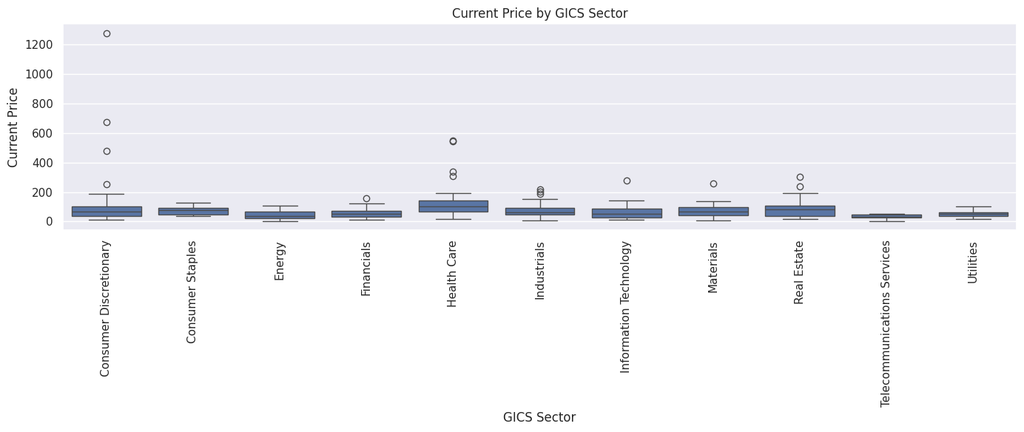

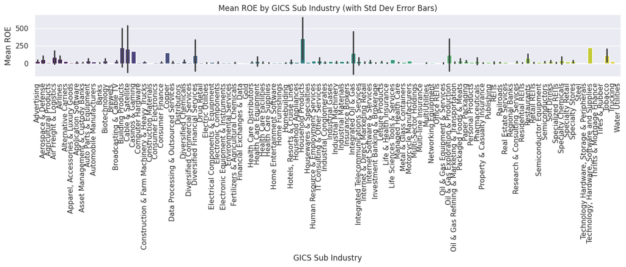

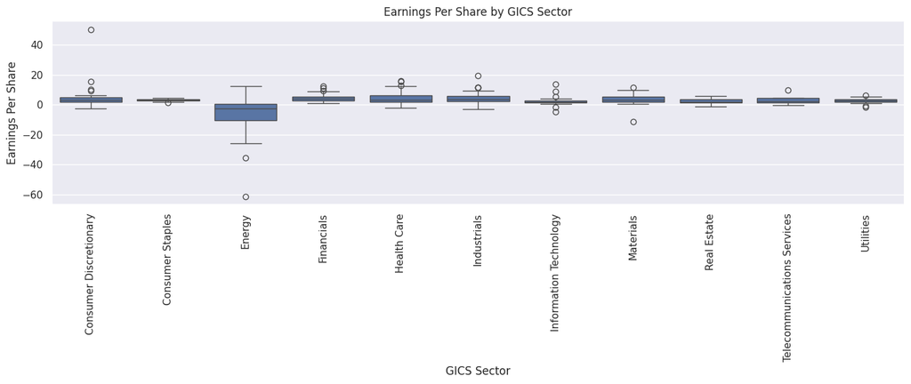

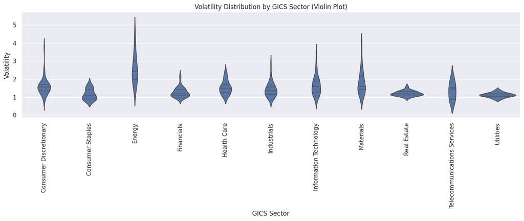

```python
# Categorical vs Numeric Analysis: Boxplots by Sector, Sub industry

# Current Price by GICS Sector
plt.figure(figsize=(14, 6));
sns.boxplot(data=df, x='GICS Sector', y='Current Price')
plt.xticks(rotation=90)
plt.title("Current Price by GICS Sector")
plt.tight_layout()
plt.show()

# Mean ROE per GICS Sub Industry with error bars (standard deviation)

plt.figure(figsize=(14, 6));
sns.barplot(data=df, x='GICS Sub Industry', y='ROE', ci='sd', palette='viridis')
plt.xticks(rotation=90)
plt.ylabel("Mean ROE")
plt.title("Mean ROE by GICS Sub Industry (with Std Dev Error Bars)")
plt.tight_layout()
plt.show()

# EPS by GICS Sector
plt.figure(figsize=(14, 6));
sns.boxplot(data=df, x='GICS Sector', y='Earnings Per Share')
plt.xticks(rotation=90)
plt.title("Earnings Per Share by GICS Sector")
plt.tight_layout()
plt.show()

# Violin plot of Volatility by GICS Sector
plt.figure(figsize=(14, 6));
sns.violinplot(data=df, x='GICS Sector', y='Volatility', inner='quartile')
plt.title("Volatility Distribution by GICS Sector (Violin Plot)")
plt.xticks(rotation=90)
plt.tight_layout()
plt.show()
```

Key Observations/Insights:

**Current Price by GICS Sector (Boxplot):**

Most sectors have a median stock price in the $50–$100 range.

Telecom and Utilities show the lowest spread and values, indicating lower-priced, possibly more regulated stocks.

- Despite price being model-insensitive (can depend on share structure), these differences hint at market sentiment and maturity of firms in each sector.

**Mean ROE by GICS Sub-Industry (w/ Std Dev Bars):**

Capital-intensive sectors (Utilities, Telecom) tend to have low mean ROE, but also low variation — stable returns.

- Use this to identify return leaders (high-ROE sub-industries) and risk-adjusted return zones.
- Sub-industries with high ROE + low std dev are prime targets for low-volatility value investing.

**EPS by GICS Sector (Boxplot):**

Telecom & Utilities show lower, stable earnings — aligned with regulated or infrastructure-heavy operations.

- EPS stability varies widely — use this with volatility plots to isolate sectors where earnings consistency aligns with stock behavior.
- May be a better indicator for long-term valuation vs. short-term price moves.

**Volatility by GICS Sector (Violin Plot):**

Energy, IT, and Materials show the widest volatility distributions.

Consumer Staples, Real Estate, Utilities show tight, low-volatility profiles.

Shapes reveal some bimodal distributions (Energy has 2 density peaks).

- This is key for risk-adjusted portfolio construction.
- Combine with EPS and ROE to segment firms into low-risk consistent performers vs. high-risk high-return opportunities.

# Appendix B : t-SNE Visualization of Cluster Separation

```python
# t-SNE Projection from PCA-reduced features
X_pca_4d = PCA(n_components=4).fit_transform(df_scaled[scaled_features_for_pca])

# Perform t-SNE on 4D PCA features
tsne = TSNE(n_components=2, perplexity=30, random_state=1)
X_tsne = tsne.fit_transform(X_pca_4d)

# Create a dataframe for plotting
tsne_df = pd.DataFrame(X_tsne, columns=["TSNE1", "TSNE2"])
tsne_df["KMeans Cluster"] = df["Cluster_4_Label"]
tsne_df["Hierarchical Cluster"] = df["Cluster_Hierarchical_Label"]

# Display
tsne_df.head(10)
```

|  | TSNE1 | TSNE2 | KMeans Cluster | Hierarchical Cluster |
| --- | --- | --- | --- | --- |
| 0 | 10.164104 | -13.827141 | High-Growth Market Leaders | Established Value Leaders |
| 1 | -2.981725 | 1.002912 | High-Growth Market Leaders | Established Value Leaders |
| 2 | 7.803209 | -4.895012 | High-Growth Market Leaders | Established Value Leaders |
| 3 | -13.363025 | -5.084235 | High-Growth Market Leaders | Established Value Leaders |
| 4 | -13.282104 | 14.496350 | Established Value Leaders | High-Growth Market Leaders |
| 5 | 0.131491 | 16.821798 | High-Growth Market Leaders | Established Value Leaders |
| 6 | 23.297052 | -15.679864 | Nonconforming / Atypical Profiles | Volatile or Undervalued Securities |
| 7 | 3.993051 | 4.804573 | High-Growth Market Leaders | Established Value Leaders |
| 8 | 6.926171 | 1.780411 | High-Growth Market Leaders | Established Value Leaders |
| 9 | 10.142077 | -4.250490 | High-Growth Market Leaders | Established Value Leaders |

Key Observations/Insights:

Strong agreement between clustering methods:

- Most records in High-Growth Market Leaders (KMeans) also appear in Established Value Leaders (Hierarchical), and vice versa.
- But some swaps exist (e.g., index 4) — indicates boundary overlap in cluster logic.

Disagreement Example (Index 4):

- KMeans: Established Value Leaders
- Hierarchical: High-Growth Market Leaders This could mean that the point lies near a cluster decision boundary, and the algorithms weigh structure or density differently.

Outlier or Niche Group (Index 6):

- KMeans: Nonconforming / Atypical Profiles
- Hierarchical: Volatile or Undervalued Securities This is likely a low-density region far from cluster centroids (confirmed by t-SNE score around TSNE1 ≈ 23).

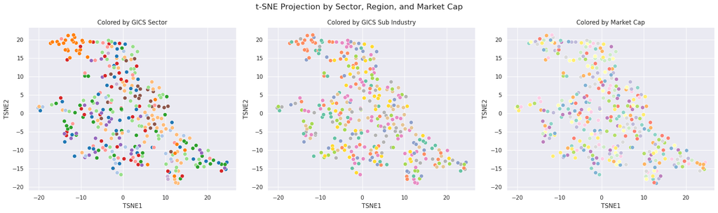

```python
# t-SNE Colored by GICS Sector, GICS Sub Industry, Market Cap

# Create t-SNE plotting DataFrame
tsne_df["GICS Sector"] = df["GICS Sector"]
tsne_df["GICS Sub Industry"] = df["GICS Sub Industry"]
tsne_df["Market Cap"] = df["Market Cap"]

# Plot side-by-side
fig, axes = plt.subplots(1, 3, figsize=(20, 6));
fig.suptitle("t-SNE Projection by Sector, Region, and Market Cap", fontsize=16)

# GICS Sector
sns.scatterplot(data=tsne_df, x="TSNE1", y="TSNE2", hue="GICS Sector", ax=axes[0], palette="tab20", s=60, legend=False)
axes[0].set_title("Colored by GICS Sector")

# Region
sns.scatterplot(data=tsne_df, x="TSNE1", y="TSNE2", hue="GICS Sub Industry", ax=axes[1], palette="Set2", s=60, legend=False)
axes[1].set_title("Colored by GICS Sub Industry")

# Market Cap Category
sns.scatterplot(data=tsne_df, x="TSNE1", y="TSNE2", hue="Market Cap", ax=axes[2], palette="Set3", s=60, legend=False)
axes[2].set_title("Colored by Market Cap")

plt.tight_layout()
plt.show()
```

Key Observations/Insights:

**Colored by GICS Sector:**

Clear vertical and horizontal banding indicates some sector-specific separation in t-SNE space.

Clusters of similar-colored points suggest that companies from the same sector often share financial profiles (revenue, ROE, valuation).

There’s also intermixing — implying overlap between sectors in financial structure (diversified conglomerates).

- While sector membership explains some variance, it’s not the sole driver — deeper attributes (like fundamentals) create cross-sector overlap.

**Colored by GICS Sub-Industry:**

Much greater dispersion and mixing compared to the sector-level view.

Some tight local clusters exist (likely niche verticals), but many sub-industries overlap or scatter, suggesting:

High within-sector variance

Diverse business models under one industry label

- Sub-industry membership has less predictive power for clustering than sector — perhaps due to broader classification or mixed financial signals.

**Colored by Market Cap:**

No distinct concentration or clear clusters emerge based solely on market cap.

Most points seem evenly distributed — but some grouping at lower TSNE1/TSNE2 values may reflect larger caps clustering in stable, high-return areas.

- Market cap does not dominate clustering structure — financial performance metrics (EPS, ROE, P/E, etc.) likely have more influence.

### Project Conclusion

```python
# Create dataframe to check original & copy datasets shape
shape_comparison = pd.DataFrame({
    "Dataset": ["data (Original)", "df (Copy)"],
    "Rows": [data.shape[0], df.shape[0]],
    "Columns": [data.shape[1], df.shape[1]]
})

# Display the DataFrame
shape_comparison
```

|  | Dataset | Rows | Columns |
| --- | --- | --- | --- |
| 0 | data (Original) | 340 | 15 |
| 1 | df (Copy) | 340 | 24 |

Observations:

- Original dataset integrity intact
- Copy dataset rows remain same

## ** Trade & Ahead Project analysis completed.**